# Week 5 Day 2 Homework

```r
# Load libraries
library(tidyverse)
library(CodeClanData)
library(lubridate)
library(scales)
```

```r
# Set theme

col_scheme <- c("#E89FE9", "#50434F", "#B6A7B5", "#F9A472", "#BD7040")
theme_qikbit <- function() {
  theme_minimal() %+replace% # replace elements we want to change
    theme(

      # grid elements
      panel.background = element_blank(),
      plot.background = element_rect(fill = "gray96", colour = NA),
      legend.background = element_rect(fill = "transparent", colour = NA),
      legend.key = element_rect(fill = "transparent", colour = NA),

      # text elements
      plot.title = element_text(size = 13,),
      plot.subtitle = element_text(size = 12),
      axis.title = element_text(size = 10),
      axis.text = element_text(size = 9),


    )
}
```

PART 1 1. Take the data in the dataset qb_revenue_breakdown and make a stacked bar chart showing the sources of revenue across the two years in the dataset.

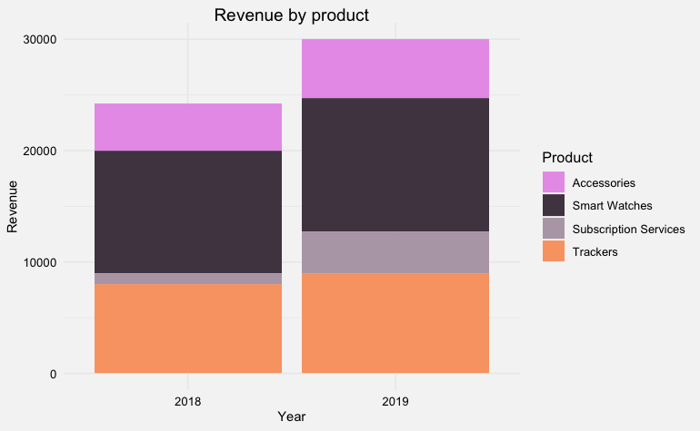

```r
qb_revenue_breakdown %>%
  ggplot() +
  aes(
    x = Year,
    y = Revenue,
    fill = Product
  ) +
  geom_bar(
    position = "stack",
    stat = "identity"
  ) +
  scale_fill_manual(values = col_scheme) +
  labs(title = "Revenue by product") +
  theme_qikbit()
```

2. Make a line chart showing monthly sales of the “flagship product” - the ‘KwikBit Unit 1’ - over the last year. This data is inside qb_monthly_sales, but you will need to use filter() or subset() (base R).

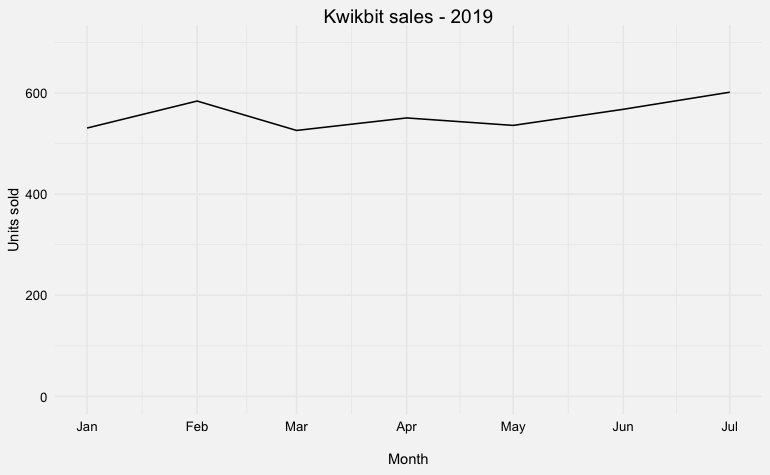

```r
qb_monthly_sales %>%
  filter(year(Date) == 2019) %>%
  filter(Cashflow == "Kwikbit Unit 1 Sales") %>%
  ggplot() +
  aes(
    x = Date,
    y = Amount
  ) +
  geom_line() +
  scale_x_date(
    breaks = "1 month",
    date_labels = "%b"
  ) +
  scale_y_continuous(limits = c(0,700)) +
  labs(
    x = "\nMonth",
    y = "Units sold",
    title = "Kwikbit sales - 2019"
  ) +
  theme_qikbit()
```

3. Make a line chart showing monthly revenue and costs over the last year. This data is also in qb_monthly_sales.

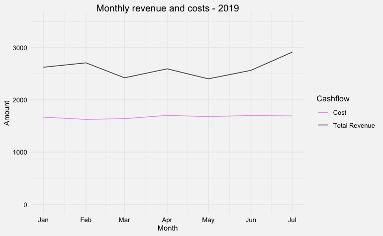

```r
qb_monthly_sales %>%
  filter(year(Date) == 2019) %>%
  filter(Cashflow %in% c("Total Revenue", "Cost")) %>%
  ggplot() +
  aes(
    x = Date,
    y = Amount,
    group = Cashflow,
    colour = Cashflow
  ) +
  geom_line() +
  scale_x_date(
    breaks = "1 month",
    date_labels = "%b"
  ) +
  scale_y_continuous(limits = c(0,3500)) +
  scale_colour_manual(values = col_scheme) +
  labs(
    x = "Month",
    title = "Monthly revenue and costs - 2019"
  ) +
  theme_qikbit()
```

4. Show annual sales of personal fitness trackers over the last 5 years broken down by company as a ribbon plot (use geom_area). This data is in qb_competitors.

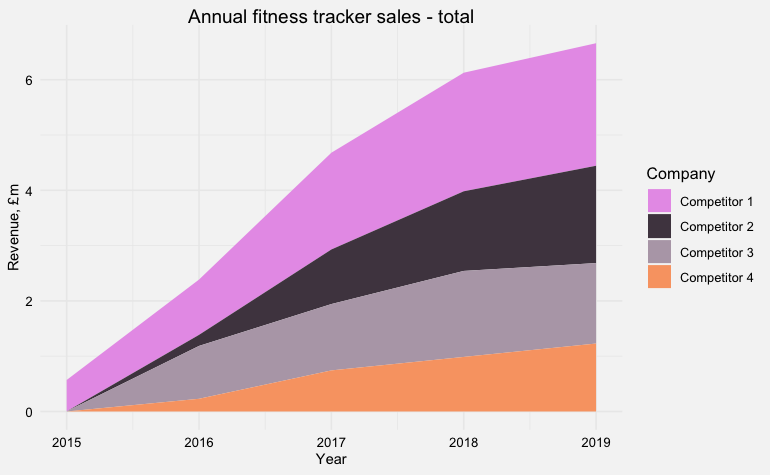

```r
qb_competitors %>%
  ggplot() +
  aes(
    x = Year,
    y = Revenue / 10^6,
    group = Company,
    fill = Company
  ) +
  geom_area() +
  scale_fill_manual(values = col_scheme) +
  labs(
    title = "Annual fitness tracker sales - total",
    y = "Revenue, £m"
  ) +
  theme_qikbit()
```

5. Now show the sales from the four competitors as a line graph. Include an extra layer that shows the data points used to make the lines.

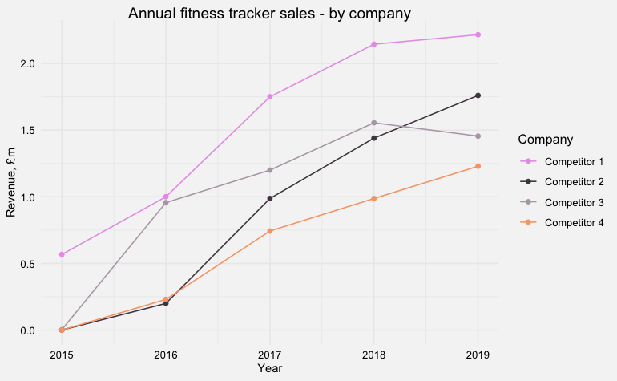

```r
qb_competitors %>%
  ggplot() +
  aes(
    x = Year,
    y = Revenue / 10^6,
    group = Company,
    colour = Company
  ) +
  geom_line() +
  geom_point() +
  scale_colour_manual(values = col_scheme) +
  labs(
    title = "Annual fitness tracker sales - by company",
    y = "Revenue, £m"
  ) +
  theme_qikbit()
```

6. Now the company wants to compare the number of steps that their device counts vs. their competitors. Make a line graph of the number of steps throughout time, and use faceting to compare between companies and people. The data for this is in qb_device_data.

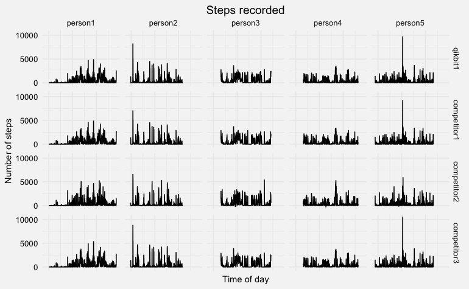

```r
qb_device_data %>%
  mutate(time = (make_datetime(year = 2021,
                month = 4,
                day = 27,
                hour = hours,
                min = mins)
                )) %>%
  ggplot() +
  aes(
    x = time,
    y = counts
  ) +
  geom_line() +
  facet_grid(device ~ id) +
  scale_y_continuous(breaks = c(0, 5000, 10000)) +
  labs(
    x = "Time of day",
    y = "Number of steps",
    title = "Steps recorded"
  ) +
   scale_colour_manual(values = col_scheme) +
  theme_qikbit() +
  theme(
    axis.text.x = element_blank(),
    axis.ticks.x = element_blank()
  )
```